# Tuango - RFM Analysis for Mobile App Push Messaging

```r
tuango <-tuango %>%
  mutate(rec_sq = radiant.data::xtile(recency, 5))%>%
  group_by(rec_sq)%>%
  mutate(freq_sq= radiant.data::xtile(frequency, 5,rev=TRUE))%>%
  ungroup()%>%
  group_by(rec_sq,freq_sq)%>%
  mutate(mon_sq =radiant.data::xtile(monetary, 5,rev=TRUE))%>%
  ungroup()%>%
  mutate(rfm_sq = paste0(rec_sq,freq_sq,mon_sq))
```

```r
breakeven_response_rate <- 1.6/(0.5*amount_spent)
breakeven_response_rate
```

```
[1] 0.01583149
```

Question7 breakeven response rate is 0.0158

```r
profit <- (mean(tuango$ordersize)*0.5-1.6)*250902
ROME<- profit/(250902*1.6)
profit
```

```
[1] 354417.3
```

```r
ROME
```

```
[1] 0.8828579
```

Quesiton8 Profit is 354417 and ROME is 88.29%

```r
tuango<- tuango%>%
  mutate(buyer = ifelse(buyer == "yes", 1, 0))
```

```r
perf_calc <- function(data,column_name){
  data <- data %>%
  group_by_at(column_name)%>%
  mutate(choose_test = mean(buyer)>breakeven_response_rate)%>%
  ungroup()
  perc_choose <- mean(data$choose_test)
  number_choose <- perc_choose *250902
  dat <-filter(data,choose_test ==TRUE)
  rep_rate<-mean(dat$buyer== 1)
  nr_resp <-number_choose*rep_rate
  cost1<-1.6*number_choose
  profit1<-amount_spent*0.5*nr_resp-cost1
  ROME1 <-profit1/cost1
  return(c(cost1,profit1,ROME1))
}
iq<-perf_calc(tuango,'rfm_iq')
sq<-perf_calc(tuango,'rfm_sq')

iq
```

```
[1] 237456.00000 447457.30505      1.88438
```

```r
sq
```

```
[1] 232891.20000 451112.52563      1.93701
```

```r
profit_iq <- iq[2]
ROME_iq <- iq[3]
profit_sq <-sq[2]
ROME_sq <- sq[3]
```

Qusetion9 For iq ,profit is 447457.3 and ROME is 1.8844 For sq ,profit is 451112.5 and ROME is 1.9370

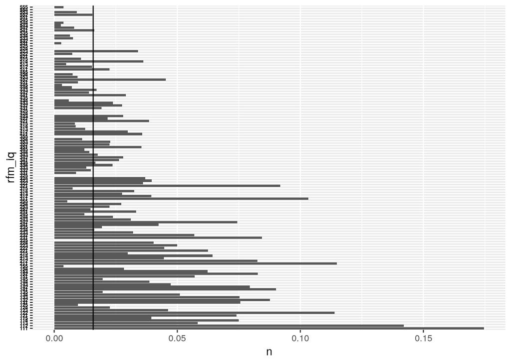

```r
plot_iq<- tuango %>%
  group_by(rfm_iq)%>%
  summarize(n= mean(buyer))%>%
  ggplot(aes(x=rfm_iq,y=n))+geom_bar(stat='identity')+geom_hline(aes(yintercept=breakeven_response_rate))+ coord_flip()+theme(axis.text.y = element_text(face="bold", color="black", size=5))
plot_sq<- tuango %>%
  group_by(rfm_sq)%>%
  summarize(n= mean(buyer))%>%
  ggplot(aes(x=rfm_sq,y=n))+geom_bar(stat='identity')+geom_hline(aes(yintercept=breakeven_response_rate))+ coord_flip()+theme(axis.text.y = element_text(face="bold", color="black", size=5))
plot(plot_iq)
```

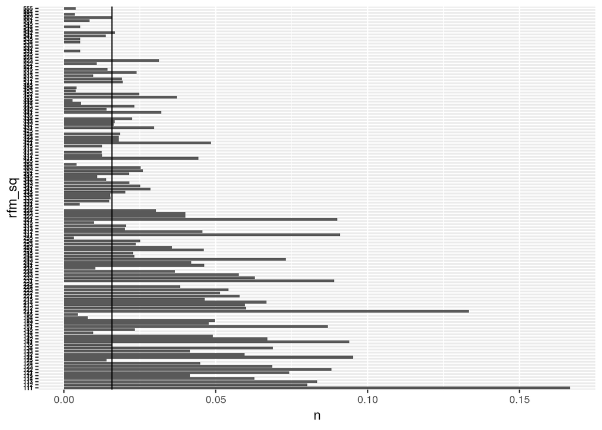

```r
plot(plot_sq)
```

```r
#question 11
perf_calc2 <- function(data,column_name){
  sq_data<- data%>%
  filter(buyer == 1)%>%
  group_by_at(column_name)%>%
  summarize(size = mean(ordersize))
  sq_data3<- data %>%
  group_by_at(column_name)%>%
  summarize(rate=mean(buyer),n=n())%>%
  right_join(sq_data,by = column_name)%>%
  mutate(breakeven_response_rate = 1.6/(size*0.5))%>%
  mutate(choose_test2 = breakeven_response_rate< rate)%>%
  filter(choose_test2 == TRUE)
  data <- data %>%
  mutate(choose_test3 = data[[column_name]]   %in% sq_data3[[column_name]]  )
  perc_choose_sq3 <- mean(data$choose_test3)
  number_choose_sq3 <- perc_choose_sq3 *250902
  dat_sq3 <- filter(data,choose_test3==TRUE)
  rep_rate_sq3<-mean(dat_sq3$buyer== 1)
  nr_resp_sq3 <-number_choose_sq3*rep_rate_sq3
  cost_sq3<-1.6*number_choose_sq3
  profit_sq3<-amount_spent*0.5*nr_resp_sq3-cost_sq3
  ROME_sq3 <-profit_sq3/cost_sq3
  return(c(profit_sq3,ROME_sq3))
}

c<-perf_calc2(tuango,'rfm_sq')
c
```

```
[1] 449379.890253      1.976624
```

```r
profit_sq3 <-c[1]
ROME_sq3 <- c[2]
```

Question11 profit is 449380 and ROME is 1.9766

```r
perf_calc3 <- function(data,column_name){
  sq_data<- data%>%
  filter(buyer == 1)%>%
  group_by_at(column_name)%>%
  summarize(size = mean(ordersize))
  sq_data3<- data %>%
  group_by_at(column_name)%>%
  summarize(rate=mean(buyer)-1.64*seprop(buyer),n=n())%>%
  right_join(sq_data,by = column_name)%>%
  mutate(breakeven_response_rate = 1.6/(size*0.5))%>%
  mutate(choose_test2 = breakeven_response_rate< rate)%>%
  filter(choose_test2 == TRUE)
  data <- data %>%
  mutate(choose_test3 = data[[column_name]]   %in% sq_data3[[column_name]]  )
  perc_choose_sq3 <- mean(data$choose_test3)
  number_choose_sq3 <- perc_choose_sq3 *250902
  dat_sq3 <- filter(data,choose_test3==TRUE)
  rep_rate_sq3<-mean(dat_sq3$buyer== 1)
  nr_resp_sq3 <-number_choose_sq3*rep_rate_sq3
  cost_sq3<-1.6*number_choose_sq3
  profit_sq3<-amount_spent*0.5*nr_resp_sq3-cost_sq3
  ROME_sq3 <-profit_sq3/cost_sq3
  return(c(profit_sq3,ROME_sq3))
}
d<- perf_calc3(tuango,'rfm_iq')
e<-perf_calc3(tuango,'rfm_sq')
d
```

```
[1] 366891.49386      3.18522
```

```r
e
```

```
[1] 403526.238628      3.010599
```

```r
profit_iq2<-d[1]
ROME_iq2<-d[2]
profit_sq2<-e[1]
ROME_sq2<-e[2]
```

Question12 Profit of iq is 366891.49386 ROME of iq is 3.185 Profit of sq is 403526.238628 ROME of sq is 3.011

Method 12 has the best ROME rate which means it is more effective.When we try to solve the standard error, when improve the ROME rate sufficiently.Even though the profit become less ,the cost we need to pay is much smaller.

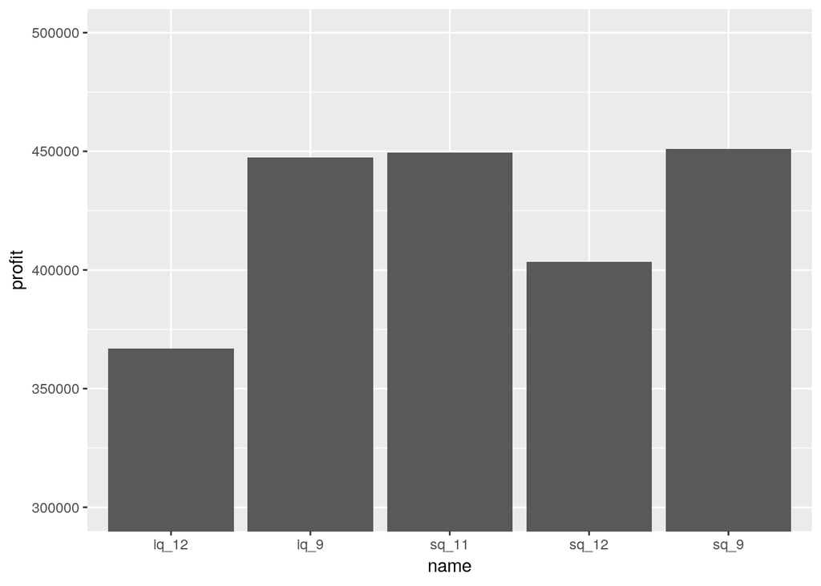

```r
library(dplyr)
bar_profit <- data.frame(name=c('iq_9','sq_9','sq_11','iq_12','sq_12'),profit=c(profit_iq,profit_sq,profit_sq3,profit_iq2,profit_sq2)) %>%
  ggplot(aes(x=name,y=profit))+geom_bar(stat = 'identity')+coord_cartesian(ylim=c(300000,500000))
bar_ROME <- data.frame(name=c('iq_9','sq_9','sq_11','iq_12','sq_12'),ROME=c(ROME_iq,ROME_sq,ROME_sq3,ROME_iq2,ROME_sq2)) %>%
  ggplot(aes(x=name,y=ROME))+geom_bar(stat = 'identity')+coord_cartesian(ylim=c(1.5,3.5))
bar_profit
```

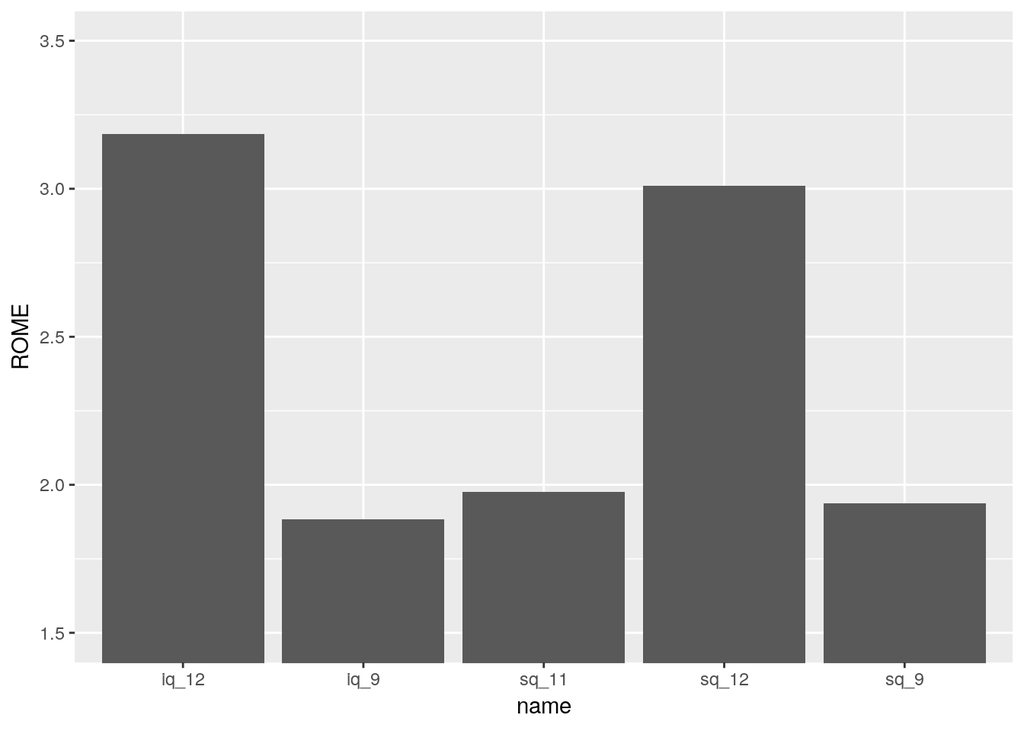

```r
bar_ROME
```

```r
#useless
perf_calc5 <- function(data,column_name){
data_new<- data%>%
  filter(buyer == 1)%>%
  group_by_at(column_name)%>%
  summarize(size = mean(ordersize))
data_new2<- data %>%
  group_by_at(column_name)%>%
  summarize(rate=mean(buyer),n=n())%>%
  right_join(data_new,by = column_name)%>%
  mutate(choose = 1.6/(size*0.5)<rate)%>%
  filter(choose == TRUE)
data <- data %>%
  mutate(choose_test3 = data[[column_name]]   %in% data_new2[[column_name]]  )
  perc_choose_sq3 <- mean(data$choose_test3)
  number_choose_sq3 <- perc_choose_sq3 *250902
  dat_sq3 <- filter(data,choose_test3==TRUE)
  rep_rate_sq3<-mean(dat_sq3$buyer== 1)
  nr_resp_sq3 <-number_choose_sq3*rep_rate_sq3
  cost_sq3<-1.6*number_choose_sq3
  profit_sq3<-amount_spent*0.5*nr_resp_sq3-cost_sq3
  ROME_sq3 <-profit_sq3/cost_sq3
  return(c(profit_sq3,ROME_sq3))
}
```